# Risk Factor Analysis

## Outcome Variable

**Outcome Variable:** ever_co

## Predictor Variables

**Intervention Variable:** parity

**Adjustment Set:**

unadjusted

## Stratifying Variables

The analysis was stratified on these variable(s):

- agecat
- studyid
- country

## Data Summary

| agecat | studyid | country | parity | ever_co | n_cell | n |
| --- | --- | --- | --- | --- | --- | --- |
| 0-24 months | COHORTS | GUATEMALA | 1 | 0 | 191 | 1341 |
| 0-24 months | COHORTS | GUATEMALA | 1 | 1 | 17 | 1341 |
| 0-24 months | COHORTS | GUATEMALA | 2 | 0 | 164 | 1341 |
| 0-24 months | COHORTS | GUATEMALA | 2 | 1 | 23 | 1341 |
| 0-24 months | COHORTS | GUATEMALA | 3+ | 0 | 838 | 1341 |
| 0-24 months | COHORTS | GUATEMALA | 3+ | 1 | 108 | 1341 |
| 0-24 months | COHORTS | INDIA | 1 | 0 | 757 | 4623 |
| 0-24 months | COHORTS | INDIA | 1 | 1 | 53 | 4623 |
| 0-24 months | COHORTS | INDIA | 2 | 0 | 1093 | 4623 |
| 0-24 months | COHORTS | INDIA | 2 | 1 | 91 | 4623 |
| 0-24 months | COHORTS | INDIA | 3+ | 0 | 2307 | 4623 |
| 0-24 months | COHORTS | INDIA | 3+ | 1 | 322 | 4623 |
| 0-24 months | COHORTS | PHILIPPINES | 1 | 0 | 586 | 3045 |
| 0-24 months | COHORTS | PHILIPPINES | 1 | 1 | 91 | 3045 |
| 0-24 months | COHORTS | PHILIPPINES | 2 | 0 | 572 | 3045 |
| 0-24 months | COHORTS | PHILIPPINES | 2 | 1 | 110 | 3045 |
| 0-24 months | COHORTS | PHILIPPINES | 3+ | 0 | 1327 | 3045 |
| 0-24 months | COHORTS | PHILIPPINES | 3+ | 1 | 359 | 3045 |
| 0-24 months | GMS-Nepal | NEPAL | 1 | 0 | 151 | 686 |
| 0-24 months | GMS-Nepal | NEPAL | 1 | 1 | 52 | 686 |
| 0-24 months | GMS-Nepal | NEPAL | 2 | 0 | 134 | 686 |
| 0-24 months | GMS-Nepal | NEPAL | 2 | 1 | 46 | 686 |
| 0-24 months | GMS-Nepal | NEPAL | 3+ | 0 | 199 | 686 |
| 0-24 months | GMS-Nepal | NEPAL | 3+ | 1 | 104 | 686 |
| 0-24 months | JiVitA-3 | BANGLADESH | 1 | 0 | 9121 | 26923 |
| 0-24 months | JiVitA-3 | BANGLADESH | 1 | 1 | 985 | 26923 |
| 0-24 months | JiVitA-3 | BANGLADESH | 2 | 0 | 8216 | 26923 |
| 0-24 months | JiVitA-3 | BANGLADESH | 2 | 1 | 711 | 26923 |
| 0-24 months | JiVitA-3 | BANGLADESH | 3+ | 0 | 7194 | 26923 |
| 0-24 months | JiVitA-3 | BANGLADESH | 3+ | 1 | 696 | 26923 |

[output cut: 168 more lines]

The following strata were considered:

- agecat: 0-24 months, studyid: COHORTS, country: GUATEMALA
- agecat: 0-24 months, studyid: COHORTS, country: INDIA
- agecat: 0-24 months, studyid: COHORTS, country: PHILIPPINES
- agecat: 0-24 months, studyid: GMS-Nepal, country: NEPAL
- agecat: 0-24 months, studyid: JiVitA-3, country: BANGLADESH
- agecat: 0-24 months, studyid: Keneba, country: GAMBIA
- agecat: 0-24 months, studyid: PROVIDE, country: BANGLADESH
- agecat: 0-24 months, studyid: SAS-CompFeed, country: INDIA
- agecat: 0-24 months, studyid: SAS-FoodSuppl, country: INDIA
- agecat: 0-24 months, studyid: TanzaniaChild2, country: TANZANIA, UNITED REPUBLIC OF
- agecat: 0-24 months, studyid: ZVITAMBO, country: ZIMBABWE
- agecat: 0-6 months, studyid: COHORTS, country: GUATEMALA
- agecat: 0-6 months, studyid: COHORTS, country: INDIA
- agecat: 0-6 months, studyid: COHORTS, country: PHILIPPINES
- agecat: 0-6 months, studyid: GMS-Nepal, country: NEPAL
- agecat: 0-6 months, studyid: JiVitA-3, country: BANGLADESH
- agecat: 0-6 months, studyid: Keneba, country: GAMBIA
- agecat: 0-6 months, studyid: PROVIDE, country: BANGLADESH
- agecat: 0-6 months, studyid: SAS-CompFeed, country: INDIA
- agecat: 0-6 months, studyid: SAS-FoodSuppl, country: INDIA
- agecat: 0-6 months, studyid: TanzaniaChild2, country: TANZANIA, UNITED REPUBLIC OF
- agecat: 0-6 months, studyid: ZVITAMBO, country: ZIMBABWE
- agecat: 6-24 months, studyid: COHORTS, country: GUATEMALA
- agecat: 6-24 months, studyid: COHORTS, country: INDIA
- agecat: 6-24 months, studyid: COHORTS, country: PHILIPPINES
- agecat: 6-24 months, studyid: GMS-Nepal, country: NEPAL
- agecat: 6-24 months, studyid: JiVitA-3, country: BANGLADESH
- agecat: 6-24 months, studyid: Keneba, country: GAMBIA
- agecat: 6-24 months, studyid: PROVIDE, country: BANGLADESH
- agecat: 6-24 months, studyid: SAS-CompFeed, country: INDIA
- agecat: 6-24 months, studyid: SAS-FoodSuppl, country: INDIA
- agecat: 6-24 months, studyid: TanzaniaChild2, country: TANZANIA, UNITED REPUBLIC OF
- agecat: 6-24 months, studyid: ZVITAMBO, country: ZIMBABWE

### Dropped Strata

Some strata were dropped due to rare outcomes:

- agecat: 0-24 months, studyid: SAS-FoodSuppl, country: INDIA
- agecat: 0-6 months, studyid: COHORTS, country: GUATEMALA
- agecat: 0-6 months, studyid: Keneba, country: GAMBIA
- agecat: 0-6 months, studyid: SAS-FoodSuppl, country: INDIA
- agecat: 6-24 months, studyid: SAS-FoodSuppl, country: INDIA

## Methods Detail

We’re interested in the causal parameters $E[Y_a]$ for all values of $a \in \mathcal{A}$. These parameters represent the mean outcome if, possibly contrary to fact, we intervened to set all units to have $A=a$. Under the randomization and positivity assumptions, these are identified by the statistical parameters $\psi_a=E_W[E_{Y|A,W}(Y|A=a,W)]$. In addition, we’re interested in the mean of $Y$, $E[Y]$ under no intervention (the observed mean). We will estimate these parameters by using SuperLearner to fit the relevant likelihood factors – $E_{Y|A,W}(Y|A=a,W)$ and $p(A=a|W)$, and then updating our likelihood fit using a joint TMLE.

For unadjusted analyses ($W=\{\}$), initial likelihoods were estimated using Lrnr_glm to estimate the simple $E(Y|A)$ and Lrnr_mean to estimate $p(A)$. For adjusted analyses, a small library containing Lrnr_glmnet, Lrnr_xgboost, and Lrnr_mean was used.

Having estimated these parameters, we will then use the delta method to estimate relative risks and attributable risks relative to a prespecified baseline level of $A$.

# Results Detail

## Results Plots

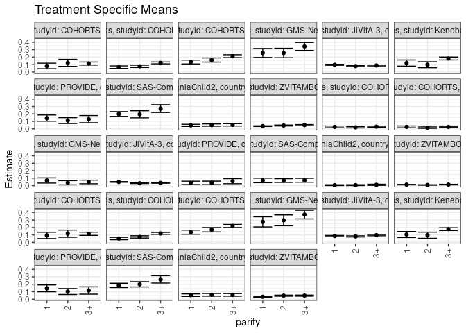

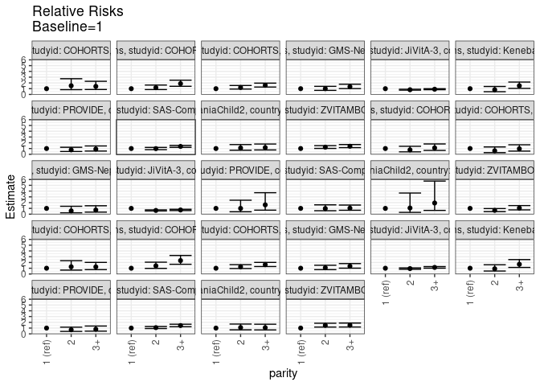

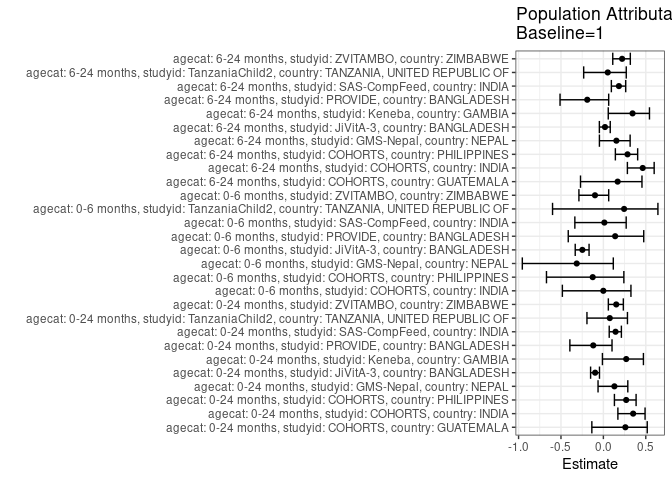

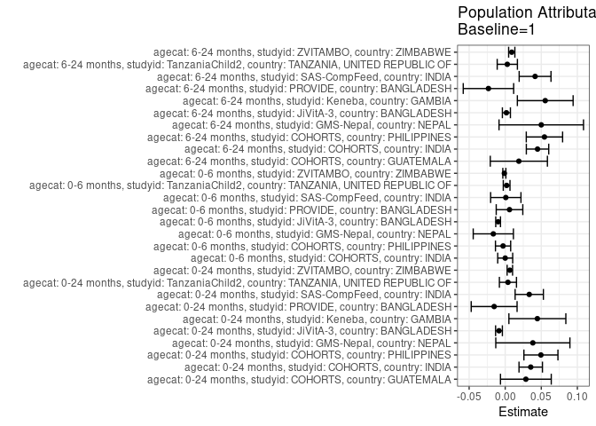

## Results Table

### Parameter: TSM

| agecat | studyid | country | intervention_level | baseline_level | estimate | ci_lower | ci_upper |
| --- | --- | --- | --- | --- | --- | --- | --- |
| 0-24 months | COHORTS | GUATEMALA | 1 | NA | 0.0817308 | 0.0444868 | 0.1189748 |
| 0-24 months | COHORTS | GUATEMALA | 2 | NA | 0.1229947 | 0.0759041 | 0.1700852 |
| 0-24 months | COHORTS | GUATEMALA | 3+ | NA | 0.1141649 | 0.0938924 | 0.1344374 |
| 0-24 months | COHORTS | INDIA | 1 | NA | 0.0654321 | 0.0484006 | 0.0824636 |
| 0-24 months | COHORTS | INDIA | 2 | NA | 0.0768581 | 0.0616842 | 0.0920320 |
| 0-24 months | COHORTS | INDIA | 3+ | NA | 0.1224800 | 0.1099469 | 0.1350132 |
| 0-24 months | COHORTS | PHILIPPINES | 1 | NA | 0.1344165 | 0.1087182 | 0.1601149 |
| 0-24 months | COHORTS | PHILIPPINES | 2 | NA | 0.1612903 | 0.1336822 | 0.1888985 |
| 0-24 months | COHORTS | PHILIPPINES | 3+ | NA | 0.2129300 | 0.1933859 | 0.2324741 |
| 0-24 months | GMS-Nepal | NEPAL | 1 | NA | 0.2561576 | 0.1960664 | 0.3162488 |
| 0-24 months | GMS-Nepal | NEPAL | 2 | NA | 0.2555556 | 0.1917898 | 0.3193213 |
| 0-24 months | GMS-Nepal | NEPAL | 3+ | NA | 0.3432343 | 0.2897355 | 0.3967331 |
| 0-24 months | JiVitA-3 | BANGLADESH | 1 | NA | 0.0974669 | 0.0908777 | 0.1040560 |
| 0-24 months | JiVitA-3 | BANGLADESH | 2 | NA | 0.0796460 | 0.0734633 | 0.0858288 |
| 0-24 months | JiVitA-3 | BANGLADESH | 3+ | NA | 0.0882129 | 0.0817674 | 0.0946585 |
| 0-24 months | Keneba | GAMBIA | 1 | NA | 0.1208333 | 0.0795874 | 0.1620792 |
| 0-24 months | Keneba | GAMBIA | 2 | NA | 0.0981308 | 0.0582628 | 0.1379989 |
| 0-24 months | Keneba | GAMBIA | 3+ | NA | 0.1817590 | 0.1624619 | 0.2010560 |
| 0-24 months | PROVIDE | BANGLADESH | 1 | NA | 0.1439114 | 0.1020917 | 0.1857311 |
| 0-24 months | PROVIDE | BANGLADESH | 2 | NA | 0.1106557 | 0.0712658 | 0.1500457 |
| 0-24 months | PROVIDE | BANGLADESH | 3+ | NA | 0.1297297 | 0.0812769 | 0.1781826 |
| 0-24 months | SAS-CompFeed | INDIA | 1 | NA | 0.1986607 | 0.1666984 | 0.2306230 |
| 0-24 months | SAS-CompFeed | INDIA | 2 | NA | 0.1949153 | 0.1473796 | 0.2424509 |
| 0-24 months | SAS-CompFeed | INDIA | 3+ | NA | 0.2714487 | 0.2193669 | 0.3235305 |
| 0-24 months | TanzaniaChild2 | TANZANIA, UNITED REPUBLIC OF | 1 | NA | 0.0462850 | 0.0319103 | 0.0606597 |
| 0-24 months | TanzaniaChild2 | TANZANIA, UNITED REPUBLIC OF | 2 | NA | 0.0505837 | 0.0351117 | 0.0660557 |
| 0-24 months | TanzaniaChild2 | TANZANIA, UNITED REPUBLIC OF | 3+ | NA | 0.0535948 | 0.0376320 | 0.0695576 |
| 0-24 months | ZVITAMBO | ZIMBABWE | 1 | NA | 0.0359640 | 0.0312548 | 0.0406733 |
| 0-24 months | ZVITAMBO | ZIMBABWE | 2 | NA | 0.0445296 | 0.0382740 | 0.0507851 |
| 0-24 months | ZVITAMBO | ZIMBABWE | 3+ | NA | 0.0502927 | 0.0433050 | 0.0572804 |

[output cut: 54 more lines]

### Parameter: E(Y)

| agecat | studyid | country | intervention_level | baseline_level | estimate | ci_lower | ci_upper |
| --- | --- | --- | --- | --- | --- | --- | --- |
| 0-24 months | COHORTS | GUATEMALA | NA | NA | 0.1103654 | 0.0935883 | 0.1271425 |
| 0-24 months | COHORTS | INDIA | NA | NA | 0.1008003 | 0.0921209 | 0.1094798 |
| 0-24 months | COHORTS | PHILIPPINES | NA | NA | 0.1839080 | 0.1701456 | 0.1976705 |
| 0-24 months | GMS-Nepal | NEPAL | NA | NA | 0.2944606 | 0.2603274 | 0.3285938 |
| 0-24 months | JiVitA-3 | BANGLADESH | NA | NA | 0.0888460 | 0.0849398 | 0.0927521 |
| 0-24 months | Keneba | GAMBIA | NA | NA | 0.1654098 | 0.1490771 | 0.1817424 |
| 0-24 months | PROVIDE | BANGLADESH | NA | NA | 0.1285714 | 0.1037574 | 0.1533855 |
| 0-24 months | SAS-CompFeed | INDIA | NA | NA | 0.2319894 | 0.1917264 | 0.2722524 |
| 0-24 months | TanzaniaChild2 | TANZANIA, UNITED REPUBLIC OF | NA | NA | 0.0500636 | 0.0412578 | 0.0588694 |
| 0-24 months | ZVITAMBO | ZIMBABWE | NA | NA | 0.0423929 | 0.0390482 | 0.0457376 |
| 0-6 months | COHORTS | INDIA | NA | NA | 0.0263336 | 0.0216247 | 0.0310424 |
| 0-6 months | COHORTS | PHILIPPINES | NA | NA | 0.0236531 | 0.0182537 | 0.0290525 |
| 0-6 months | GMS-Nepal | NEPAL | NA | NA | 0.0524781 | 0.0357793 | 0.0691770 |
| 0-6 months | JiVitA-3 | BANGLADESH | NA | NA | 0.0396778 | 0.0371765 | 0.0421791 |
| 0-6 months | PROVIDE | BANGLADESH | NA | NA | 0.0428571 | 0.0278427 | 0.0578716 |
| 0-6 months | SAS-CompFeed | INDIA | NA | NA | 0.0704787 | 0.0478990 | 0.0930584 |
| 0-6 months | TanzaniaChild2 | TANZANIA, UNITED REPUBLIC OF | NA | NA | 0.0080611 | 0.0044503 | 0.0116719 |
| 0-6 months | ZVITAMBO | ZIMBABWE | NA | NA | 0.0120621 | 0.0102437 | 0.0138805 |
| 6-24 months | COHORTS | GUATEMALA | NA | NA | 0.1123039 | 0.0945135 | 0.1300942 |
| 6-24 months | COHORTS | INDIA | NA | NA | 0.0965883 | 0.0877969 | 0.1053797 |
| 6-24 months | COHORTS | PHILIPPINES | NA | NA | 0.1908832 | 0.1763448 | 0.2054216 |
| 6-24 months | GMS-Nepal | NEPAL | NA | NA | 0.3254237 | 0.2875855 | 0.3632619 |
| 6-24 months | JiVitA-3 | BANGLADESH | NA | NA | 0.0869213 | 0.0822621 | 0.0915805 |
| 6-24 months | Keneba | GAMBIA | NA | NA | 0.1612064 | 0.1447669 | 0.1776460 |
| 6-24 months | PROVIDE | BANGLADESH | NA | NA | 0.1221498 | 0.0962275 | 0.1480722 |
| 6-24 months | SAS-CompFeed | INDIA | NA | NA | 0.2260619 | 0.1909133 | 0.2612105 |
| 6-24 months | TanzaniaChild2 | TANZANIA, UNITED REPUBLIC OF | NA | NA | 0.0563948 | 0.0462467 | 0.0665428 |
| 6-24 months | ZVITAMBO | ZIMBABWE | NA | NA | 0.0410655 | 0.0373248 | 0.0448061 |

### Parameter: RR

| agecat | studyid | country | intervention_level | baseline_level | estimate | ci_lower | ci_upper |
| --- | --- | --- | --- | --- | --- | --- | --- |
| 0-24 months | COHORTS | GUATEMALA | 1 | 1 | 1.0000000 | 1.0000000 | 1.0000000 |
| 0-24 months | COHORTS | GUATEMALA | 2 | 1 | 1.5048757 | 0.8298824 | 2.7288819 |
| 0-24 months | COHORTS | GUATEMALA | 3+ | 1 | 1.3968412 | 0.8565408 | 2.2779597 |
| 0-24 months | COHORTS | INDIA | 1 | 1 | 1.0000000 | 1.0000000 | 1.0000000 |
| 0-24 months | COHORTS | INDIA | 2 | 1 | 1.1746239 | 0.8472598 | 1.6284750 |
| 0-24 months | COHORTS | INDIA | 3+ | 1 | 1.8718646 | 1.4151709 | 2.4759391 |
| 0-24 months | COHORTS | PHILIPPINES | 1 | 1 | 1.0000000 | 1.0000000 | 1.0000000 |
| 0-24 months | COHORTS | PHILIPPINES | 2 | 1 | 1.1999291 | 0.9283450 | 1.5509643 |
| 0-24 months | COHORTS | PHILIPPINES | 3+ | 1 | 1.5841057 | 1.2813878 | 1.9583383 |
| 0-24 months | GMS-Nepal | NEPAL | 1 | 1 | 1.0000000 | 1.0000000 | 1.0000000 |
| 0-24 months | GMS-Nepal | NEPAL | 2 | 1 | 0.9976496 | 0.7083408 | 1.4051211 |
| 0-24 months | GMS-Nepal | NEPAL | 3+ | 1 | 1.3399340 | 1.0110331 | 1.7758302 |
| 0-24 months | JiVitA-3 | BANGLADESH | 1 | 1 | 1.0000000 | 1.0000000 | 1.0000000 |
| 0-24 months | JiVitA-3 | BANGLADESH | 2 | 1 | 0.8171601 | 0.7416054 | 0.9004123 |
| 0-24 months | JiVitA-3 | BANGLADESH | 3+ | 1 | 0.9050557 | 0.8208880 | 0.9978533 |
| 0-24 months | Keneba | GAMBIA | 1 | 1 | 1.0000000 | 1.0000000 | 1.0000000 |
| 0-24 months | Keneba | GAMBIA | 2 | 1 | 0.8121173 | 0.4777120 | 1.3806113 |
| 0-24 months | Keneba | GAMBIA | 3+ | 1 | 1.5042121 | 1.0521064 | 2.1505942 |
| 0-24 months | PROVIDE | BANGLADESH | 1 | 1 | 1.0000000 | 1.0000000 | 1.0000000 |
| 0-24 months | PROVIDE | BANGLADESH | 2 | 1 | 0.7689155 | 0.4856371 | 1.2174338 |
| 0-24 months | PROVIDE | BANGLADESH | 3+ | 1 | 0.9014553 | 0.5615987 | 1.4469792 |
| 0-24 months | SAS-CompFeed | INDIA | 1 | 1 | 1.0000000 | 1.0000000 | 1.0000000 |
| 0-24 months | SAS-CompFeed | INDIA | 2 | 1 | 0.9811464 | 0.8070433 | 1.1928087 |
| 0-24 months | SAS-CompFeed | INDIA | 3+ | 1 | 1.3663933 | 1.2089727 | 1.5443116 |
| 0-24 months | TanzaniaChild2 | TANZANIA, UNITED REPUBLIC OF | 1 | 1 | 1.0000000 | 1.0000000 | 1.0000000 |
| 0-24 months | TanzaniaChild2 | TANZANIA, UNITED REPUBLIC OF | 2 | 1 | 1.0928732 | 0.7067416 | 1.6899697 |
| 0-24 months | TanzaniaChild2 | TANZANIA, UNITED REPUBLIC OF | 3+ | 1 | 1.1579291 | 0.7530130 | 1.7805799 |
| 0-24 months | ZVITAMBO | ZIMBABWE | 1 | 1 | 1.0000000 | 1.0000000 | 1.0000000 |
| 0-24 months | ZVITAMBO | ZIMBABWE | 2 | 1 | 1.2381693 | 1.0218247 | 1.5003193 |
| 0-24 months | ZVITAMBO | ZIMBABWE | 3+ | 1 | 1.3984167 | 1.1553698 | 1.6925916 |

[output cut: 54 more lines]

### Parameter: PAR

| agecat | studyid | country | intervention_level | baseline_level | estimate | ci_lower | ci_upper |
| --- | --- | --- | --- | --- | --- | --- | --- |
| 0-24 months | COHORTS | GUATEMALA | 1 | NA | 0.0286346 | -0.0065546 | 0.0638239 |
| 0-24 months | COHORTS | INDIA | 1 | NA | 0.0353682 | 0.0191276 | 0.0516089 |
| 0-24 months | COHORTS | PHILIPPINES | 1 | NA | 0.0494915 | 0.0259086 | 0.0730744 |
| 0-24 months | GMS-Nepal | NEPAL | 1 | NA | 0.0383030 | -0.0130676 | 0.0896736 |
| 0-24 months | JiVitA-3 | BANGLADESH | 1 | NA | -0.0086209 | -0.0133211 | -0.0039207 |
| 0-24 months | Keneba | GAMBIA | 1 | NA | 0.0445764 | 0.0051122 | 0.0840407 |
| 0-24 months | PROVIDE | BANGLADESH | 1 | NA | -0.0153400 | -0.0471282 | 0.0164481 |
| 0-24 months | SAS-CompFeed | INDIA | 1 | NA | 0.0333287 | 0.0137346 | 0.0529228 |
| 0-24 months | TanzaniaChild2 | TANZANIA, UNITED REPUBLIC OF | 1 | NA | 0.0037786 | -0.0080630 | 0.0156202 |
| 0-24 months | ZVITAMBO | ZIMBABWE | 1 | NA | 0.0064289 | 0.0026532 | 0.0102046 |
| 0-6 months | COHORTS | INDIA | 1 | NA | -0.0000169 | -0.0103937 | 0.0103599 |
| 0-6 months | COHORTS | PHILIPPINES | 1 | NA | -0.0029741 | -0.0135120 | 0.0075638 |
| 0-6 months | GMS-Nepal | NEPAL | 1 | NA | -0.0164874 | -0.0443355 | 0.0113608 |
| 0-6 months | JiVitA-3 | BANGLADESH | 1 | NA | -0.0098291 | -0.0131206 | -0.0065376 |
| 0-6 months | PROVIDE | BANGLADESH | 1 | NA | 0.0059568 | -0.0124634 | 0.0243770 |
| 0-6 months | SAS-CompFeed | INDIA | 1 | NA | 0.0008158 | -0.0201979 | 0.0218295 |
| 0-6 months | TanzaniaChild2 | TANZANIA, UNITED REPUBLIC OF | 1 | NA | 0.0019710 | -0.0026802 | 0.0066221 |
| 0-6 months | ZVITAMBO | ZIMBABWE | 1 | NA | -0.0011929 | -0.0033092 | 0.0009234 |
| 6-24 months | COHORTS | GUATEMALA | 1 | NA | 0.0188973 | -0.0206964 | 0.0584909 |
| 6-24 months | COHORTS | INDIA | 1 | NA | 0.0447955 | 0.0292749 | 0.0603160 |
| 6-24 months | COHORTS | PHILIPPINES | 1 | NA | 0.0543700 | 0.0291954 | 0.0795447 |
| 6-24 months | GMS-Nepal | NEPAL | 1 | NA | 0.0499746 | -0.0085665 | 0.1085157 |
| 6-24 months | JiVitA-3 | BANGLADESH | 1 | NA | 0.0016476 | -0.0039145 | 0.0072098 |
| 6-24 months | Keneba | GAMBIA | 1 | NA | 0.0554796 | 0.0168380 | 0.0941211 |
| 6-24 months | PROVIDE | BANGLADESH | 1 | NA | -0.0232246 | -0.0581637 | 0.0117145 |
| 6-24 months | SAS-CompFeed | INDIA | 1 | NA | 0.0414096 | 0.0193523 | 0.0634670 |
| 6-24 months | TanzaniaChild2 | TANZANIA, UNITED REPUBLIC OF | 1 | NA | 0.0029029 | -0.0111028 | 0.0169087 |
| 6-24 months | ZVITAMBO | ZIMBABWE | 1 | NA | 0.0090744 | 0.0047616 | 0.0133873 |

### Parameter: PAF

| agecat | studyid | country | intervention_level | baseline_level | estimate | ci_lower | ci_upper |
| --- | --- | --- | --- | --- | --- | --- | --- |
| 0-24 months | COHORTS | GUATEMALA | 1 | NA | 0.2594530 | -0.1359703 | 0.5172322 |
| 0-24 months | COHORTS | INDIA | 1 | NA | 0.3508743 | 0.1711203 | 0.4916461 |
| 0-24 months | COHORTS | PHILIPPINES | 1 | NA | 0.2691100 | 0.1302095 | 0.3858290 |
| 0-24 months | GMS-Nepal | NEPAL | 1 | NA | 0.1300785 | -0.0628832 | 0.2880089 |
| 0-24 months | JiVitA-3 | BANGLADESH | 1 | NA | -0.0970318 | -0.1506686 | -0.0458951 |
| 0-24 months | Keneba | GAMBIA | 1 | NA | 0.2694909 | -0.0112031 | 0.4722687 |
| 0-24 months | PROVIDE | BANGLADESH | 1 | NA | -0.1193112 | -0.3950884 | 0.1019511 |
| 0-24 months | SAS-CompFeed | INDIA | 1 | NA | 0.1436648 | 0.0689590 | 0.2123763 |
| 0-24 months | TanzaniaChild2 | TANZANIA, UNITED REPUBLIC OF | 1 | NA | 0.0754764 | -0.1936321 | 0.2839134 |
| 0-24 months | ZVITAMBO | ZIMBABWE | 1 | NA | 0.1516504 | 0.0585725 | 0.2355258 |
| 0-6 months | COHORTS | INDIA | 1 | NA | -0.0006419 | -0.4835574 | 0.3250789 |
| 0-6 months | COHORTS | PHILIPPINES | 1 | NA | -0.1257396 | -0.6709957 | 0.2415961 |
| 0-6 months | GMS-Nepal | NEPAL | 1 | NA | -0.3141762 | -0.9558762 | 0.1169895 |
| 0-6 months | JiVitA-3 | BANGLADESH | 1 | NA | -0.2477234 | -0.3319849 | -0.1687922 |
| 0-6 months | PROVIDE | BANGLADESH | 1 | NA | 0.1389914 | -0.4142101 | 0.4757951 |
| 0-6 months | SAS-CompFeed | INDIA | 1 | NA | 0.0115752 | -0.3363813 | 0.2689334 |
| 0-6 months | TanzaniaChild2 | TANZANIA, UNITED REPUBLIC OF | 1 | NA | 0.2445029 | -0.5993898 | 0.6431289 |
| 0-6 months | ZVITAMBO | ZIMBABWE | 1 | NA | -0.0988978 | -0.2884090 | 0.0627383 |
| 6-24 months | COHORTS | GUATEMALA | 1 | NA | 0.1682692 | -0.2695733 | 0.4551113 |
| 6-24 months | COHORTS | INDIA | 1 | NA | 0.4637773 | 0.2831145 | 0.5989112 |
| 6-24 months | COHORTS | PHILIPPINES | 1 | NA | 0.2848341 | 0.1414317 | 0.4042846 |
| 6-24 months | GMS-Nepal | NEPAL | 1 | NA | 0.1535679 | -0.0466686 | 0.3154974 |
| 6-24 months | JiVitA-3 | BANGLADESH | 1 | NA | 0.0189555 | -0.0472406 | 0.0809673 |
| 6-24 months | Keneba | GAMBIA | 1 | NA | 0.3441523 | 0.0575609 | 0.5435926 |
| 6-24 months | PROVIDE | BANGLADESH | 1 | NA | -0.1901322 | -0.5110407 | 0.0626232 |
| 6-24 months | SAS-CompFeed | INDIA | 1 | NA | 0.1831783 | 0.0941375 | 0.2634669 |
| 6-24 months | TanzaniaChild2 | TANZANIA, UNITED REPUBLIC OF | 1 | NA | 0.0514753 | -0.2322238 | 0.2698573 |
| 6-24 months | ZVITAMBO | ZIMBABWE | 1 | NA | 0.2209747 | 0.1106176 | 0.3176383 |